# Proje Rapo : Metin Tunçbilek 200401088

# Q1 : Problem tanımı

Şirketimiz ** Capital İnvest**. Problemimiz *Şirketimizin artan müşteri sayısından dolayı ve financal analizlerin müşteriye iletiminde oluşan zaman maaliyeti verimliliği azaltmaktadır. Yeni sistem’de Bitcoin geçmiş verilerini R programlama dilinde modeller ile eğitilip tahmin yapması ve arayüz ile müşterilerin kullanımına sunulması hedeflenmektedir. Bu sayede makine öğrenmesi methodlarını kullanarak daha fazla müşteriye hizmet vermek hedeflenmektedir.*

# Q2 : Proje Amacı

[Bitcoin Historical Data](https://www.kaggle.com/datasets/armanzhalgasbayev/bitcoin-historical-data-2021-2023) adli Kaggle veri setini kullanarak iş problemini *Şirketimizin artan müşteri sayısından dolayı ve financal analizlerin müşteriye iletiminde oluşan zaman maaliyeti verimliliği azaltmaktadır.* ve **LSTM gibi derin öğrenme algoritmaları ile model eğitmeli ve tahmin yaptırmalıyız** yöntemler kullanarak çözmeyi amaçlıyoruz. Bu sayede problemi azaltmayı / yok etmeyi ya da kar arttırımına katkıda bulunmayı planlıyoruz.

# Q3 : Veri seti keşifsel analizi

| Start | End | Open | High | Low | Close | Volume | Market Cap |
| --- | --- | --- | --- | --- | --- | --- | --- |
| 2024-01-04 | 2024-01-05 | 42803.62 | 44664.55 | 42635.44 | 44188.15 | 163824018762 | 851408939294 |
| 2024-01-03 | 2024-01-04 | 44955.47 | 45474.95 | 40931.46 | 42818.03 | 99309168813 | 860140132319 |
| 2024-01-02 | 2024-01-03 | 44245.11 | 45846.21 | 44245.11 | 44957.63 | 46637934136 | 885978270304 |
| 2024-01-01 | 2024-01-02 | 42396.02 | 44122.03 | 42227.99 | 44122.03 | 25433295177 | 838286312920 |
| 2023-12-31 | 2024-01-01 | 42206.16 | 42814.17 | 42000.02 | 42224.09 | 25914047573 | 831346753476 |
| 2023-12-30 | 2023-12-31 | 42040.12 | 42570.01 | 41539.76 | 42198.85 | 34758190469 | 824740192163 |
| 2023-12-29 | 2023-12-30 | 42631.14 | 43033.78 | 41683.16 | 42057.41 | 35252318490 | 830544031611 |
| 2023-12-28 | 2023-12-29 | 43421.73 | 43730.03 | 42321.07 | 42592.06 | 35332722355 | 840522742625 |
| 2023-12-27 | 2023-12-28 | 42484.06 | 43624.64 | 42154.05 | 43384.25 | 33682997794 | 838520902844 |
| 2023-12-26 | 2023-12-27 | 43573.22 | 43573.22 | 41723.24 | 42519.80 | 32196800353 | 836347069498 |

```
[1] "spec_tbl_df" "tbl_df"      "tbl"         "data.frame"
```

```
[1] "numeric"
```

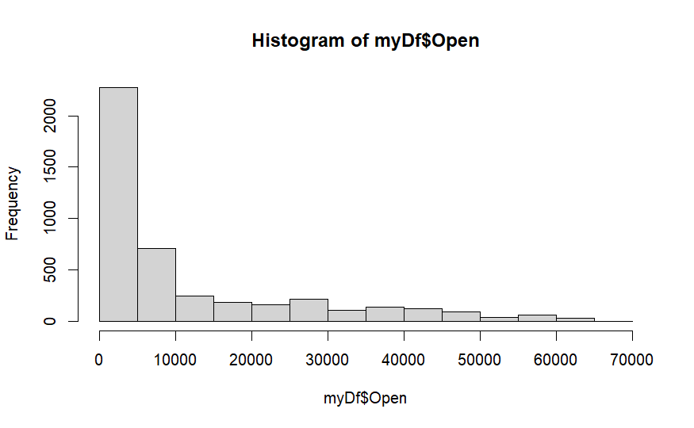

# Q4 : Veri seti ön işlemesi

##veri setini günümüzden geçmişe giderek ilerlemektedir bu yüzden ters çevirilmiştir

##işimize yarayacak verileri şeçtik

# Q6 : Veri analizi

# Q7 : Sonuç değerlendirme, tavsiyeler

Sonuçlar istenilen bilgiyi elde edememiştir. Seçilen veri seti model eğitilmediği sürece veri grafikleri ve çıktılarına bakarak anlamlı bir sonuç vermemektedir. Bitcoin fiyat verileri tekrarlanmayan bir veri olduğu için sınıflandırma yapılamamıştır. LSTM modeli ile geçmişten günümüze Open sutunu Volume , High ,Low sutunlarının eğitilip tahmin ile çıktı alınması planlanmıştır, fakat r dilinde LSTM modeli eğitilememiştir Veri ön işleme adımı yapıldı histogram grafiği çizdirildi ama müşteriye fayda sağlayacak bir bilgi elde edilememektedir.

Eğer LSTM veya diğer derin öğrenme modelleri ile Dataset eğitilebilirse RNN, CNN gibi model türleri anlamlı bir bilgiyi müşteriye sunabilir.